# Analysis

# Variable Description

- *author_id*: user identifier
- *month*: period of reference
- *monthly_commits*: total number of commits made in a month
- *monthly_project*: number of different project a user commited in a month
- *first_commit*: month in which user made the first recorded commit
- *last_commit*: month in which user made the last recorded commit
- *total_commits*: total number of commits made by a user over time
- *number_project*: total number of projects an user made contribution to
- *time active*: number of days between first and last commit

# Multitasking

```r
period <- 'w'
loc <- paste('C:/Users/mmore/Dropbox/Econometrics II - TA/Project/GitHub/Data/commits/productive_users_50_2_',
             period,
             '.csv',
             sep='')
df_pu <- read.csv(loc)
```

```r
multi_task_t <- 2

tot_active <- df_pu %>% filter(period_project>=1) %>%
                        summarise(n())
tot_active_multi <- df_pu %>% filter(period_project>=multi_task_t) %>%
                        summarise(n())

N_obs <- nrow(df_pu)
period_active <- round(as.numeric(tot_active/nrow(df_pu))*100,2)
period_multi_task <- round(as.numeric(tot_active_multi/tot_active)*100,2)
```

We define an user *i* as active in month *t* if the user has contributed to at least one project *j*. We define that agent *i* did multi-tasking in month *t* if she contributed to at least two different projects. In the selected sample, we have:

- 13135364 pair of user-month observations
- 8.72% of the pairs *(i,t)* (user-month) have at least one commit, i.e. the user *i* is active is active in month *t*
- 16.74% of the pairs *(i,t)* (user-month) in which usere is active are subject to multitasking.
- In total, we have 1.46% observations in which agents perform multi-tasking

```r
multi_task_t <- 2
threshold <- 500

tot_active_500 <- df_pu %>% filter(period_project>=1) %>%
                            filter(total_commits>=threshold) %>%
                            summarise(n())

tot_active_multi_500 <- df_pu %>%
                    filter(total_commits>=threshold) %>%
                    filter(period_project>=multi_task_t) %>%
                    summarise(n())

N_obs_500 <- df_pu %>%
             filter(total_commits>=threshold)%>%
             summarise(n())

N_obs_500 <- as.numeric(N_obs_500)


period_active_500 <- round(as.numeric(tot_active_500/N_obs_500)*100,2)
period_multi_task_500 <- round(as.numeric(tot_active_multi_500/tot_active_500)*100,2)
```

- 1773654 pair of user-month observations
- 24.03% of the pairs *(i,t)* (user-month) have at least one commit, i.e. the user *i* is active is active in month *t*
- 24.55% of the pairs *(i,t)* (user-month) in which usere is active are subject to multitasking.
- In total, we have 5.9% observations in which agents perform multi-tasking

```r
thresholds <- seq(50,1550,100)
store <- matrix(0,6,length(thresholds))

i <- 1

for (threshold in thresholds){

  store[1,i] <- as.numeric(df_pu %>% filter(total_commits>=threshold) %>% summarise(n_distinct(author_id)))
  df_temp <- df_pu %>% filter(total_commits>=threshold) %>%
                                     group_by(author_id) %>%
                                     mutate(multi = max(period_project)) %>%
                                     filter(multi>1)

  store[2,i] <- round(length(unique(df_temp$author_id))/store[1,i] * 100,2)

  df_temp <- df_pu %>% filter(total_commits>=threshold)
  store[3,i] <- nrow(df_temp)

  df_temp <- df_pu %>% filter(period_project>1) %>%
                       filter(total_commits>=threshold)

  store[4,i] <- round(nrow(df_temp)  * 100 / store[3,i],2)
  df_temp <- df_pu %>% filter(period_project>=1) %>%
                       filter(total_commits>=threshold)

  store[5,i] <- round(nrow(df_temp) * 100 / store[3,i],2)

  store[6,i] <- as.numeric(df_pu %>% filter(total_commits>=threshold) %>% summarise(sum(period_commits)))


  i <- i + 1

}

rownames(store) <- c('N.Users','Share of Users Multitasking at least 1 Period','N. Obs','Share of Obs. with multi-tasking','Share of Obs. with Commits','Tot. Number of Commits')
colnames(store) <- paste('>=',thresholds,sep='')
View(store)
rm(df_temp)
```

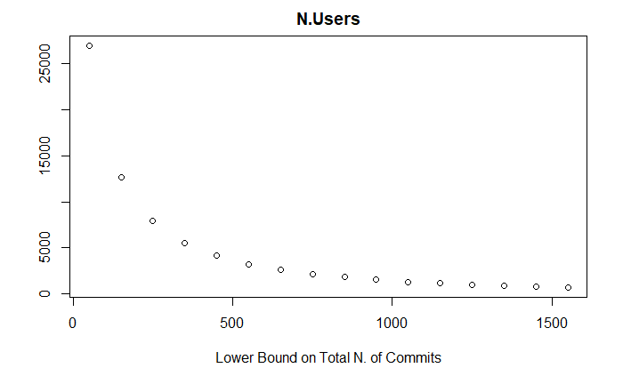

```r
plot(thresholds,store[1,],
     xlab='Lower Bound on Total N. of Commits',
     ylab='',
     main=rownames(store)[1])
```

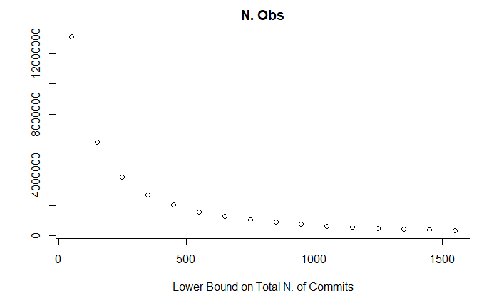

```r
plot(thresholds,store[3,],
     xlab='Lower Bound on Total N. of Commits',
     ylab='',
     main=rownames(store)[3])
```

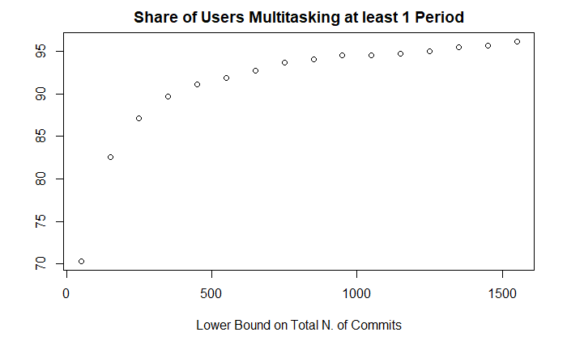

```r
plot(thresholds,store[2,],
     xlab='Lower Bound on Total N. of Commits',
     ylab='',
     main=rownames(store)[2])
```

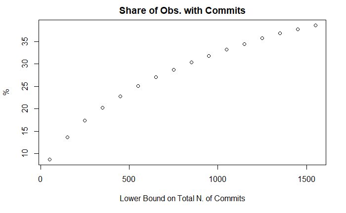

```r
plot(thresholds,store[5,],
     xlab='Lower Bound on Total N. of Commits',
     ylab='%',
     main=rownames(store)[5])
```

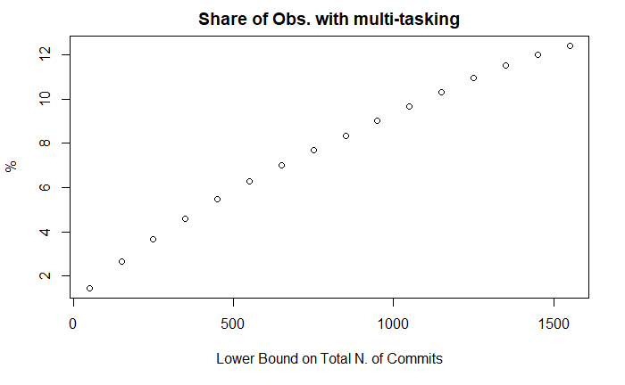

```r
plot(thresholds,store[4,],
     xlab='Lower Bound on Total N. of Commits',
     ylab='%',
     main=rownames(store)[4])
```

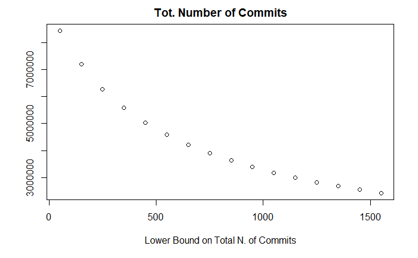

```r
plot(thresholds,store[6,],
     xlab='Lower Bound on Total N. of Commits',
     ylab='',
     main=rownames(store)[6])
```

```r
NA
NA
```